# **Performance Assessment | D206 Data Cleaning**

Ryan L. Buchanan  
Student ID: 001826691  
Masters Data Analytics (12/01/2020)  
Program Mentor: Dan Estes  
(385) 432-9281 (MST)  
rbuch49@wgu.edu

## Part I: Research Question

### **A. Question or Decision**:

Can we determine which individual customers are at high risk of churn? And, can we determine which features are most significant to churn?

### **B. Required Variables**:

The data set is 10,000 customer records of a popular telecommunications company. The dependent variable (target) in question is whether or not each customer has continued or discontinued service within the last month. This column is titled "Churn."  
Independent variables or predictors that may lead to identifying a relationship with the dependent variable of "Churn" within the dataset include:

1. Services that each customer signed up for (for example, multiple phone lines, technical support add-ons or streaming media)
2. Customer account information (customers' tenure with the company, payment methods, bandwidth usage, etc.)
3. Customer demographics (gender, marital status, income, etc.).
4. Finally, there are eight independent variables that represent responses customer-perceived importance of company services and features.

The data is both numerical (as in the yearly GB bandwidth usage; customer annual income) and categorical (a "Yes" or "No" for Churn; customer job).

## Part II: Data-Cleaning Plan

### **C1. Plan to Find Anomalies**:

My approach will include:  
1. Back up my data and the process I am following as a copy to my machine and, since this is a manageable dataset, to GitHub using command line and gitbash.  
2. Read the data set into Python using Pandas' read_csv command.  
3. Evaluate the data struture to better understand input data.  
4. Naming the dataset as a the variable "churn_df" and subsequent useful slices of the dataframe as "df".  
5. Examine potential misspellings, awkward variable naming & missing data.  
6. Find outliers that may create or hide statistical significance using histograms.  
7. Imputing records missing data with meaningful measures of central tendency (mean, median or mode) or simply remove outliers that are several standard deviations above the mean.  
*Referenced & paraphrased within above plan (Larose, 2019, p. 29-43).

### **C2. Justification of Approach**:

Though the data seems to be inexplicably missing quite a bit of data (such as the many NAs in customer tenure with the company) from apparently random columns, this approach seems like a good first approach in order to put the data in better working order without needing to involve methods of initial data collection or querying the data-gatherers on reasons for missing information. Also, this the first dataset that I've clean, so I followed the procedures practice in the performance lab as well as tips from StackOverflow and other tutorial resources.

### **C3. Justification of Tools**:

I will use the Python programming language as I have a bit of a background in Python having studied machine learning independently over the last year before beginning this masters program and its ability to perform many things right "out of the box" (Poulson, 2016, section 2). Python provides clean, intuitive and readable syntax that has become ubiquitous across in the data science industry. Also, I find the Jupyter notebooks a convenient way to run code visually, in its attractive single document markdown format, the ability to display results of code and graphic visualizations and provide crystal-clear running documentation for future reference. A thorough installation and importation of Python packages and libraries will provide specially designed code to perfom complex data science tasks rather than personally building them from scratch. This will include:  
• NumPy - to work with arrays  
• Pandas - to load datasets  
• Matplotlib - to plot charts  
• Scikit-learn - for machine learning model classes  
• SciPy - for mathematical problems, specifically linear algebra transformations  
• Seaborn - for high-level interface and atttractive visualizations

A quick, precise example of loading a dataset and creating a variable efficiently is using to call the Pandas library and its subsequent "read_csv" function in order to manipulate our data as a dataframe:  
import pandas as pd  
df = pd.read_csv('Data.csv')

### **C4. Provide the Code**:

```python
# Install necessary packages
!pip install pandas
!pip install numpy
!pip install scipy
!pip install sklearn
!pip install matplotlib
```

```python
# Standard imports
import numpy as np
import pandas as pd
from sklearn.preprocessing import scale
from sklearn.decomposition import PCA

import seaborn as sns
import matplotlib.pyplot as plt
%matplotlib inline
```

```python
# Load data set into Pandas dataframe
churn_df = pd.read_csv('churn_raw_data.csv')
```

```python
# Display Churn dataframe
churn_df
```

|  | Unnamed: 0 | CaseOrder | Customer_id | Interaction | City | State | County | Zip | Lat | Lng | ... | MonthlyCharge | Bandwidth_GB_Year | item1 | item2 | item3 | item4 | item5 | item6 | item7 | item8 |
| --- | --- | --- | --- | --- | --- | --- | --- | --- | --- | --- | --- | --- | --- | --- | --- | --- | --- | --- | --- | --- | --- |
| 0 | 1 | 1 | K409198 | aa90260b-4141-4a24-8e36-b04ce1f4f77b | Point Baker | AK | Prince of Wales-Hyder | 99927 | 56.25100 | -133.37571 | ... | 171.449762 | 904.536110 | 5 | 5 | 5 | 3 | 4 | 4 | 3 | 4 |
| 1 | 2 | 2 | S120509 | fb76459f-c047-4a9d-8af9-e0f7d4ac2524 | West Branch | MI | Ogemaw | 48661 | 44.32893 | -84.24080 | ... | 242.948015 | 800.982766 | 3 | 4 | 3 | 3 | 4 | 3 | 4 | 4 |
| 2 | 3 | 3 | K191035 | 344d114c-3736-4be5-98f7-c72c281e2d35 | Yamhill | OR | Yamhill | 97148 | 45.35589 | -123.24657 | ... | 159.440398 | 2054.706961 | 4 | 4 | 2 | 4 | 4 | 3 | 3 | 3 |
| 3 | 4 | 4 | D90850 | abfa2b40-2d43-4994-b15a-989b8c79e311 | Del Mar | CA | San Diego | 92014 | 32.96687 | -117.24798 | ... | 120.249493 | 2164.579412 | 4 | 4 | 4 | 2 | 5 | 4 | 3 | 3 |
| 4 | 5 | 5 | K662701 | 68a861fd-0d20-4e51-a587-8a90407ee574 | Needville | TX | Fort Bend | 77461 | 29.38012 | -95.80673 | ... | 150.761216 | 271.493436 | 4 | 4 | 4 | 3 | 4 | 4 | 4 | 5 |
| ... | ... | ... | ... | ... | ... | ... | ... | ... | ... | ... | ... | ... | ... | ... | ... | ... | ... | ... | ... | ... | ... |
| 9995 | 9996 | 9996 | M324793 | 45deb5a2-ae04-4518-bf0b-c82db8dbe4a4 | Mount Holly | VT | Rutland | 5758 | 43.43391 | -72.78734 | ... | 159.828800 | 6511.253000 | 3 | 2 | 3 | 3 | 4 | 3 | 2 | 3 |
| 9996 | 9997 | 9997 | D861732 | 6e96b921-0c09-4993-bbda-a1ac6411061a | Clarksville | TN | Montgomery | 37042 | 36.56907 | -87.41694 | ... | 208.856400 | 5695.952000 | 4 | 5 | 5 | 4 | 4 | 5 | 2 | 5 |
| 9997 | 9998 | 9998 | I243405 | e8307ddf-9a01-4fff-bc59-4742e03fd24f | Mobeetie | TX | Wheeler | 79061 | 35.52039 | -100.44180 | ... | 168.220900 | 4159.306000 | 4 | 4 | 4 | 4 | 4 | 4 | 4 | 5 |
| 9998 | 9999 | 9999 | I641617 | 3775ccfc-0052-4107-81ae-9657f81ecdf3 | Carrollton | GA | Carroll | 30117 | 33.58016 | -85.13241 | ... | 252.628600 | 6468.457000 | 4 | 4 | 6 | 4 | 3 | 3 | 5 | 4 |
| 9999 | 10000 | 10000 | T38070 | 9de5fb6e-bd33-4995-aec8-f01d0172a499 | Clarkesville | GA | Habersham | 30523 | 34.70783 | -83.53648 | ... | 218.371000 | 5857.586000 | 2 | 2 | 3 | 3 | 3 | 3 | 4 | 1 |

10000 rows × 52 columns

```python
# List of Dataframe Columns
df = churn_df.columns
print(df)
```

```
Index(['Unnamed: 0', 'CaseOrder', 'Customer_id', 'Interaction', 'City',
       'State', 'County', 'Zip', 'Lat', 'Lng', 'Population', 'Area',
       'Timezone', 'Job', 'Children', 'Age', 'Education', 'Employment',
       'Income', 'Marital', 'Gender', 'Churn', 'Outage_sec_perweek', 'Email',
       'Contacts', 'Yearly_equip_failure', 'Techie', 'Contract', 'Port_modem',
       'Tablet', 'InternetService', 'Phone', 'Multiple', 'OnlineSecurity',
       'OnlineBackup', 'DeviceProtection', 'TechSupport', 'StreamingTV',
       'StreamingMovies', 'PaperlessBilling', 'PaymentMethod', 'Tenure',
       'MonthlyCharge', 'Bandwidth_GB_Year', 'item1', 'item2', 'item3',
       'item4', 'item5', 'item6', 'item7', 'item8'],
      dtype='object')
```

```python
# Remove redundant "Unnamed" column at beginning & display first five records
df = churn_df.drop(churn_df.columns[0], axis = 1)
df.head()
```

|  | CaseOrder | Customer_id | Interaction | City | State | County | Zip | Lat | Lng | Population | ... | MonthlyCharge | Bandwidth_GB_Year | item1 | item2 | item3 | item4 | item5 | item6 | item7 | item8 |
| --- | --- | --- | --- | --- | --- | --- | --- | --- | --- | --- | --- | --- | --- | --- | --- | --- | --- | --- | --- | --- | --- |
| 0 | 1 | K409198 | aa90260b-4141-4a24-8e36-b04ce1f4f77b | Point Baker | AK | Prince of Wales-Hyder | 99927 | 56.25100 | -133.37571 | 38 | ... | 171.449762 | 904.536110 | 5 | 5 | 5 | 3 | 4 | 4 | 3 | 4 |
| 1 | 2 | S120509 | fb76459f-c047-4a9d-8af9-e0f7d4ac2524 | West Branch | MI | Ogemaw | 48661 | 44.32893 | -84.24080 | 10446 | ... | 242.948015 | 800.982766 | 3 | 4 | 3 | 3 | 4 | 3 | 4 | 4 |
| 2 | 3 | K191035 | 344d114c-3736-4be5-98f7-c72c281e2d35 | Yamhill | OR | Yamhill | 97148 | 45.35589 | -123.24657 | 3735 | ... | 159.440398 | 2054.706961 | 4 | 4 | 2 | 4 | 4 | 3 | 3 | 3 |
| 3 | 4 | D90850 | abfa2b40-2d43-4994-b15a-989b8c79e311 | Del Mar | CA | San Diego | 92014 | 32.96687 | -117.24798 | 13863 | ... | 120.249493 | 2164.579412 | 4 | 4 | 4 | 2 | 5 | 4 | 3 | 3 |
| 4 | 5 | K662701 | 68a861fd-0d20-4e51-a587-8a90407ee574 | Needville | TX | Fort Bend | 77461 | 29.38012 | -95.80673 | 11352 | ... | 150.761216 | 271.493436 | 4 | 4 | 4 | 3 | 4 | 4 | 4 | 5 |

5 rows × 51 columns

```python
# Rename last 8 survey columns for better description of variables
df.rename(columns = {'item1':'Responses',
                    'item2':'Fixes',
                     'item3':'Replacements',
                     'item4':'Reliability',
                     'item5':'Options',
                     'item6':'Respectfulness',
                     'item7':'Courteous',
                     'item8':'Listening'},
          inplace=True)
```

```python
# Find number of records and columns of dataset
df.shape
```

```
(10000, 51)
```

```python
# Describe Churn dataset statistics
df.describe()
```

|  | CaseOrder | Zip | Lat | Lng | Population | Children | Age | Income | Outage_sec_perweek | Email | ... | MonthlyCharge | Bandwidth_GB_Year | Responses | Fixes | Replacements | Reliability | Options | Respectfulness | Courteous | Listening |
| --- | --- | --- | --- | --- | --- | --- | --- | --- | --- | --- | --- | --- | --- | --- | --- | --- | --- | --- | --- | --- | --- |
| count | 10000.00000 | 10000.000000 | 10000.000000 | 10000.000000 | 10000.000000 | 7505.000000 | 7525.000000 | 7510.000000 | 10000.000000 | 10000.000000 | ... | 10000.000000 | 8979.000000 | 10000.000000 | 10000.000000 | 10000.000000 | 10000.000000 | 10000.000000 | 10000.000000 | 10000.000000 | 10000.000000 |
| mean | 5000.50000 | 49153.319600 | 38.757567 | -90.782536 | 9756.562400 | 2.095936 | 53.275748 | 39936.762226 | 11.452955 | 12.016000 | ... | 174.076305 | 3398.842752 | 3.490800 | 3.505100 | 3.487000 | 3.497500 | 3.492900 | 3.497300 | 3.509500 | 3.495600 |
| std | 2886.89568 | 27532.196108 | 5.437389 | 15.156142 | 14432.698671 | 2.154758 | 20.753928 | 28358.469482 | 7.025921 | 3.025898 | ... | 43.335473 | 2187.396807 | 1.037797 | 1.034641 | 1.027977 | 1.025816 | 1.024819 | 1.033586 | 1.028502 | 1.028633 |
| min | 1.00000 | 601.000000 | 17.966120 | -171.688150 | 0.000000 | 0.000000 | 18.000000 | 740.660000 | -1.348571 | 1.000000 | ... | 77.505230 | 155.506715 | 1.000000 | 1.000000 | 1.000000 | 1.000000 | 1.000000 | 1.000000 | 1.000000 | 1.000000 |
| 25% | 2500.75000 | 26292.500000 | 35.341828 | -97.082813 | 738.000000 | 0.000000 | 35.000000 | 19285.522500 | 8.054362 | 10.000000 | ... | 141.071078 | 1234.110529 | 3.000000 | 3.000000 | 3.000000 | 3.000000 | 3.000000 | 3.000000 | 3.000000 | 3.000000 |
| 50% | 5000.50000 | 48869.500000 | 39.395800 | -87.918800 | 2910.500000 | 1.000000 | 53.000000 | 33186.785000 | 10.202896 | 12.000000 | ... | 169.915400 | 3382.424000 | 3.000000 | 4.000000 | 3.000000 | 3.000000 | 3.000000 | 3.000000 | 4.000000 | 3.000000 |
| 75% | 7500.25000 | 71866.500000 | 42.106908 | -80.088745 | 13168.000000 | 3.000000 | 71.000000 | 53472.395000 | 12.487644 | 14.000000 | ... | 203.777441 | 5587.096500 | 4.000000 | 4.000000 | 4.000000 | 4.000000 | 4.000000 | 4.000000 | 4.000000 | 4.000000 |
| max | 10000.00000 | 99929.000000 | 70.640660 | -65.667850 | 111850.000000 | 10.000000 | 89.000000 | 258900.700000 | 47.049280 | 23.000000 | ... | 315.878600 | 7158.982000 | 7.000000 | 7.000000 | 8.000000 | 7.000000 | 7.000000 | 8.000000 | 7.000000 | 8.000000 |

8 rows × 23 columns

```python
# Remove less meaningful variables from statistics description
df_stats = df.drop(columns=['CaseOrder', 'Zip', 'Lat', 'Lng'])
df_stats.describe()
```

|  | Population | Children | Age | Income | Outage_sec_perweek | Email | Contacts | Yearly_equip_failure | Tenure | MonthlyCharge | Bandwidth_GB_Year | Responses | Fixes | Replacements | Reliability | Options | Respectfulness | Courteous | Listening |
| --- | --- | --- | --- | --- | --- | --- | --- | --- | --- | --- | --- | --- | --- | --- | --- | --- | --- | --- | --- |
| count | 10000.000000 | 7505.000000 | 7525.000000 | 7510.000000 | 10000.000000 | 10000.000000 | 10000.000000 | 10000.000000 | 9069.000000 | 10000.000000 | 8979.000000 | 10000.000000 | 10000.000000 | 10000.000000 | 10000.000000 | 10000.000000 | 10000.000000 | 10000.000000 | 10000.000000 |
| mean | 9756.562400 | 2.095936 | 53.275748 | 39936.762226 | 11.452955 | 12.016000 | 0.994200 | 0.398000 | 34.498858 | 174.076305 | 3398.842752 | 3.490800 | 3.505100 | 3.487000 | 3.497500 | 3.492900 | 3.497300 | 3.509500 | 3.495600 |
| std | 14432.698671 | 2.154758 | 20.753928 | 28358.469482 | 7.025921 | 3.025898 | 0.988466 | 0.635953 | 26.438904 | 43.335473 | 2187.396807 | 1.037797 | 1.034641 | 1.027977 | 1.025816 | 1.024819 | 1.033586 | 1.028502 | 1.028633 |
| min | 0.000000 | 0.000000 | 18.000000 | 740.660000 | -1.348571 | 1.000000 | 0.000000 | 0.000000 | 1.000259 | 77.505230 | 155.506715 | 1.000000 | 1.000000 | 1.000000 | 1.000000 | 1.000000 | 1.000000 | 1.000000 | 1.000000 |
| 25% | 738.000000 | 0.000000 | 35.000000 | 19285.522500 | 8.054362 | 10.000000 | 0.000000 | 0.000000 | 7.890442 | 141.071078 | 1234.110529 | 3.000000 | 3.000000 | 3.000000 | 3.000000 | 3.000000 | 3.000000 | 3.000000 | 3.000000 |
| 50% | 2910.500000 | 1.000000 | 53.000000 | 33186.785000 | 10.202896 | 12.000000 | 1.000000 | 0.000000 | 36.196030 | 169.915400 | 3382.424000 | 3.000000 | 4.000000 | 3.000000 | 3.000000 | 3.000000 | 3.000000 | 4.000000 | 3.000000 |
| 75% | 13168.000000 | 3.000000 | 71.000000 | 53472.395000 | 12.487644 | 14.000000 | 2.000000 | 1.000000 | 61.426670 | 203.777441 | 5587.096500 | 4.000000 | 4.000000 | 4.000000 | 4.000000 | 4.000000 | 4.000000 | 4.000000 | 4.000000 |
| max | 111850.000000 | 10.000000 | 89.000000 | 258900.700000 | 47.049280 | 23.000000 | 7.000000 | 6.000000 | 71.999280 | 315.878600 | 7158.982000 | 7.000000 | 7.000000 | 8.000000 | 7.000000 | 7.000000 | 8.000000 | 7.000000 | 8.000000 |

```python
# Calculate Churn Rate
df.Churn.value_counts() / len(df)
```

```
No     0.735
Yes    0.265
Name: Churn, dtype: float64
```

```python
# Review data types (numerical => "int64" & "float64"; & categorical => "object") in data set
df.dtypes
```

```
CaseOrder                 int64
Customer_id              object
Interaction              object
City                     object
State                    object
County                   object
Zip                       int64
Lat                     float64
Lng                     float64
Population                int64
Area                     object
Timezone                 object
Job                      object
Children                float64
Age                     float64
Education                object
Employment               object
Income                  float64
Marital                  object
Gender                   object
Churn                    object
Outage_sec_perweek      float64
Email                     int64
Contacts                  int64
Yearly_equip_failure      int64
Techie                   object
Contract                 object
Port_modem               object
Tablet                   object
InternetService          object
Phone                    object
Multiple                 object
OnlineSecurity           object
OnlineBackup             object
DeviceProtection         object
TechSupport              object
StreamingTV              object
StreamingMovies          object
PaperlessBilling         object
PaymentMethod            object
Tenure                  float64
MonthlyCharge           float64
Bandwidth_GB_Year       float64
Responses                 int64
Fixes                     int64
Replacements              int64
Reliability               int64
Options                   int64
Respectfulness            int64
Courteous                 int64
Listening                 int64
dtype: object
```

```python
# Re-validate column data types and missing values
df.columns.to_series().groupby(df.dtypes).groups
```

```
{dtype('int64'): Index(['CaseOrder', 'Zip', 'Population', 'Email', 'Contacts',
        'Yearly_equip_failure', 'Responses', 'Fixes', 'Replacements',
        'Reliability', 'Options', 'Respectfulness', 'Courteous', 'Listening'],
       dtype='object'),
 dtype('float64'): Index(['Lat', 'Lng', 'Children', 'Age', 'Income', 'Outage_sec_perweek',
        'Tenure', 'MonthlyCharge', 'Bandwidth_GB_Year'],
       dtype='object'),
 dtype('O'): Index(['Customer_id', 'Interaction', 'City', 'State', 'County', 'Area',
        'Timezone', 'Job', 'Education', 'Employment', 'Marital', 'Gender',
        'Churn', 'Techie', 'Contract', 'Port_modem', 'Tablet',
        'InternetService', 'Phone', 'Multiple', 'OnlineSecurity',
        'OnlineBackup', 'DeviceProtection', 'TechSupport', 'StreamingTV',
        'StreamingMovies', 'PaperlessBilling', 'PaymentMethod'],
       dtype='object')}
```

```python
# Find missing values
df.isnull()
```

|  | CaseOrder | Customer_id | Interaction | City | State | County | Zip | Lat | Lng | Population | ... | MonthlyCharge | Bandwidth_GB_Year | Responses | Fixes | Replacements | Reliability | Options | Respectfulness | Courteous | Listening |
| --- | --- | --- | --- | --- | --- | --- | --- | --- | --- | --- | --- | --- | --- | --- | --- | --- | --- | --- | --- | --- | --- |
| 0 | False | False | False | False | False | False | False | False | False | False | ... | False | False | False | False | False | False | False | False | False | False |
| 1 | False | False | False | False | False | False | False | False | False | False | ... | False | False | False | False | False | False | False | False | False | False |
| 2 | False | False | False | False | False | False | False | False | False | False | ... | False | False | False | False | False | False | False | False | False | False |
| 3 | False | False | False | False | False | False | False | False | False | False | ... | False | False | False | False | False | False | False | False | False | False |
| 4 | False | False | False | False | False | False | False | False | False | False | ... | False | False | False | False | False | False | False | False | False | False |
| ... | ... | ... | ... | ... | ... | ... | ... | ... | ... | ... | ... | ... | ... | ... | ... | ... | ... | ... | ... | ... | ... |
| 9995 | False | False | False | False | False | False | False | False | False | False | ... | False | False | False | False | False | False | False | False | False | False |
| 9996 | False | False | False | False | False | False | False | False | False | False | ... | False | False | False | False | False | False | False | False | False | False |
| 9997 | False | False | False | False | False | False | False | False | False | False | ... | False | False | False | False | False | False | False | False | False | False |
| 9998 | False | False | False | False | False | False | False | False | False | False | ... | False | False | False | False | False | False | False | False | False | False |
| 9999 | False | False | False | False | False | False | False | False | False | False | ... | False | False | False | False | False | False | False | False | False | False |

10000 rows × 51 columns

```python
# Access only rows from dataframe containing missing values
df.isnull().any(axis=1)
```

```
0        True
1       False
2        True
3       False
4       False
        ...
9995     True
9996     True
9997     True
9998    False
9999     True
Length: 10000, dtype: bool
```

```python
# Woah, lots of empty fields!  Immediately noticeable as "True" in columns of "Children", "Age", "Income", "Techie", "Phone", "Tenure"
# Display the specific columns with NAs
df.isna().any()
```

```
CaseOrder               False
Customer_id             False
Interaction             False
City                    False
State                   False
County                  False
Zip                     False
Lat                     False
Lng                     False
Population              False
Area                    False
Timezone                False
Job                     False
Children                 True
Age                      True
Education               False
Employment              False
Income                   True
Marital                 False
Gender                  False
Churn                   False
Outage_sec_perweek      False
Email                   False
Contacts                False
Yearly_equip_failure    False
Techie                   True
Contract                False
Port_modem              False
Tablet                  False
InternetService         False
Phone                    True
Multiple                False
OnlineSecurity          False
OnlineBackup            False
DeviceProtection        False
TechSupport              True
StreamingTV             False
StreamingMovies         False
PaperlessBilling        False
PaymentMethod           False
Tenure                   True
MonthlyCharge           False
Bandwidth_GB_Year        True
Responses               False
Fixes                   False
Replacements            False
Reliability             False
Options                 False
Respectfulness          False
Courteous               False
Listening               False
dtype: bool
```

```python
# Confirm missing observations numbers
data_nulls = df.isnull().sum()
print(data_nulls)
```

```
CaseOrder                  0
Customer_id                0
Interaction                0
City                       0
State                      0
County                     0
Zip                        0
Lat                        0
Lng                        0
Population                 0
Area                       0
Timezone                   0
Job                        0
Children                2495
Age                     2475
Education                  0
Employment                 0
Income                  2490
Marital                    0
Gender                     0
Churn                      0
Outage_sec_perweek         0
Email                      0
Contacts                   0
Yearly_equip_failure       0
Techie                  2477
Contract                   0
Port_modem                 0
Tablet                     0
InternetService            0
Phone                   1026
Multiple                   0
OnlineSecurity             0
OnlineBackup               0
DeviceProtection           0
TechSupport              991
StreamingTV                0
StreamingMovies            0
PaperlessBilling           0
PaymentMethod              0
Tenure                   931
MonthlyCharge              0
Bandwidth_GB_Year       1021
Responses                  0
Fixes                      0
Replacements               0
Reliability                0
Options                    0
Respectfulness             0
Courteous                  0
Listening                  0
dtype: int64
```

```python
# Store rows with missing values in a new variable
rows_with_missing_values = df.isnull().any(axis=1)
df[rows_with_missing_values]
```

|  | CaseOrder | Customer_id | Interaction | City | State | County | Zip | Lat | Lng | Population | ... | MonthlyCharge | Bandwidth_GB_Year | Responses | Fixes | Replacements | Reliability | Options | Respectfulness | Courteous | Listening |
| --- | --- | --- | --- | --- | --- | --- | --- | --- | --- | --- | --- | --- | --- | --- | --- | --- | --- | --- | --- | --- | --- |
| 0 | 1 | K409198 | aa90260b-4141-4a24-8e36-b04ce1f4f77b | Point Baker | AK | Prince of Wales-Hyder | 99927 | 56.25100 | -133.37571 | 38 | ... | 171.449762 | 904.536110 | 5 | 5 | 5 | 3 | 4 | 4 | 3 | 4 |
| 2 | 3 | K191035 | 344d114c-3736-4be5-98f7-c72c281e2d35 | Yamhill | OR | Yamhill | 97148 | 45.35589 | -123.24657 | 3735 | ... | 159.440398 | 2054.706961 | 4 | 4 | 2 | 4 | 4 | 3 | 3 | 3 |
| 5 | 6 | W303516 | 2b451d12-6c2b-4cea-a295-ba1d6bced078 | Fort Valley | GA | Peach | 31030 | 32.57032 | -83.89040 | 17701 | ... | 184.401558 | 1039.357983 | 3 | 3 | 3 | 2 | 4 | 3 | 3 | 3 |
| 6 | 7 | U335188 | 6630d501-838c-4be4-a59c-6f58c814ed6a | Pioneer | TN | Scott | 37847 | 36.43420 | -84.27892 | 2535 | ... | 200.064886 | 1907.242972 | 6 | 5 | 6 | 4 | 1 | 5 | 5 | 5 |
| 7 | 8 | V538685 | 70ddaa89-b726-49dc-9022-2d655e4c7936 | Oklahoma City | OK | Oklahoma | 73109 | 35.43313 | -97.52463 | 23144 | ... | 114.754111 | 979.612708 | 2 | 2 | 2 | 5 | 2 | 3 | 4 | 5 |
| ... | ... | ... | ... | ... | ... | ... | ... | ... | ... | ... | ... | ... | ... | ... | ... | ... | ... | ... | ... | ... | ... |
| 9994 | 9995 | P175475 | c60df12b-a50b-4397-ae57-98381a0d3960 | West Kill | NY | Greene | 12492 | 42.18491 | -74.33574 | 210 | ... | 143.687900 | 4945.756000 | 4 | 3 | 4 | 4 | 3 | 3 | 4 | 4 |
| 9995 | 9996 | M324793 | 45deb5a2-ae04-4518-bf0b-c82db8dbe4a4 | Mount Holly | VT | Rutland | 5758 | 43.43391 | -72.78734 | 640 | ... | 159.828800 | 6511.253000 | 3 | 2 | 3 | 3 | 4 | 3 | 2 | 3 |
| 9996 | 9997 | D861732 | 6e96b921-0c09-4993-bbda-a1ac6411061a | Clarksville | TN | Montgomery | 37042 | 36.56907 | -87.41694 | 77168 | ... | 208.856400 | 5695.952000 | 4 | 5 | 5 | 4 | 4 | 5 | 2 | 5 |
| 9997 | 9998 | I243405 | e8307ddf-9a01-4fff-bc59-4742e03fd24f | Mobeetie | TX | Wheeler | 79061 | 35.52039 | -100.44180 | 406 | ... | 168.220900 | 4159.306000 | 4 | 4 | 4 | 4 | 4 | 4 | 4 | 5 |
| 9999 | 10000 | T38070 | 9de5fb6e-bd33-4995-aec8-f01d0172a499 | Clarkesville | GA | Habersham | 30523 | 34.70783 | -83.53648 | 12230 | ... | 218.371000 | 5857.586000 | 2 | 2 | 3 | 3 | 3 | 3 | 4 | 1 |

7867 rows × 51 columns

```python
# Examine columns for misspellings in categorical variables using unique() method
df['Employment'].unique()
```

```
array(['Part Time', 'Retired', 'Student', 'Full Time', 'Unemployed'],
      dtype=object)
```

```python
df['Area'].unique()
```

```
array(['Urban', 'Suburban', 'Rural'], dtype=object)
```

```python
df['Timezone'].unique()
```

```
array(['America/Sitka', 'America/Detroit', 'America/Los_Angeles',
       'America/Chicago', 'America/New_York', 'America/Puerto_Rico',
       'America/Denver', 'America/Menominee', 'America/Phoenix',
       'America/Indiana/Indianapolis', 'America/Boise',
       'America/Kentucky/Louisville', 'Pacific/Honolulu',
       'America/Indiana/Petersburg', 'America/Nome', 'America/Anchorage',
       'America/Indiana/Knox', 'America/Juneau', 'America/Toronto',
       'America/Indiana/Winamac', 'America/Indiana/Vincennes',
       'America/North_Dakota/New_Salem', 'America/Indiana/Tell_City',
       'America/Indiana/Marengo', 'America/Ojinaga'], dtype=object)
```

```python
# Well then, how many unique jobs are there and will this variable help us out much?
len(df['Job'].unique())
```

```
639
```

```python
df['Children'].unique()
```

```
array([nan,  1.,  4.,  0.,  3.,  2.,  7.,  5.,  9.,  6., 10.,  8.])
```

```python
df['Age'].unique()
```

```
array([68., 27., 50., 48., 83., nan, 49., 86., 23., 56., 30., 39., 63.,
       60., 61., 52., 75., 77., 47., 70., 69., 45., 40., 82., 26., 25.,
       66., 72., 41., 44., 43., 84., 59., 31., 51., 58., 73., 33., 42.,
       81., 87., 54., 67., 46., 24., 20., 71., 32., 29., 80., 53., 79.,
       65., 35., 34., 74., 55., 76., 57., 38., 78., 19., 36., 88., 62.,
       37., 28., 22., 85., 89., 18., 21., 64.])
```

```python
# Examine age range
age_range = df['Age'].unique()
print(sorted(age_range))
```

```
[23.0, 25.0, 26.0, 27.0, 30.0, 31.0, 39.0, 40.0, 41.0, 43.0, 44.0, 45.0, 47.0, 48.0, 49.0, 50.0, 51.0, 52.0, 59.0, 61.0, 68.0, 83.0, nan, 18.0, 19.0, 20.0, 21.0, 22.0, 24.0, 28.0, 29.0, 32.0, 33.0, 34.0, 35.0, 36.0, 37.0, 38.0, 42.0, 46.0, 53.0, 54.0, 55.0, 56.0, 57.0, 58.0, 60.0, 62.0, 63.0, 64.0, …
```

```python
df['Education'].unique()
```

```
array(["Master's Degree", 'Regular High School Diploma',
       'Doctorate Degree', 'No Schooling Completed', "Associate's Degree",
       "Bachelor's Degree", 'Some College, Less than 1 Year',
       'GED or Alternative Credential',
       'Some College, 1 or More Years, No Degree',
       '9th Grade to 12th Grade, No Diploma',
       'Nursery School to 8th Grade', 'Professional School Degree'],
      dtype=object)
```

```python
df['Employment'].unique()
```

```
array(['Part Time', 'Retired', 'Student', 'Full Time', 'Unemployed'],
      dtype=object)
```

```python
df['Marital'].unique()
```

```
array(['Widowed', 'Married', 'Separated', 'Never Married', 'Divorced'],
      dtype=object)
```

```python
df['Gender'].unique()
```

```
array(['Male', 'Female', 'Prefer not to answer'], dtype=object)
```

```python
df['Contract'].unique()
```

```
array(['One year', 'Month-to-month', 'Two Year'], dtype=object)
```

```python
df['PaymentMethod'].unique()
```

```
array(['Credit Card (automatic)', 'Bank Transfer(automatic)',
       'Mailed Check', 'Electronic Check'], dtype=object)
```

```python
# Display any duplicate rows in the dataframe.
data_duplicates = df.loc[df.duplicated()]
print(data_duplicates)
```

```
Empty DataFrame
Columns: [CaseOrder, Customer_id, Interaction, City, State, County, Zip, Lat, Lng, Population, Area, Timezone, Job, Children, Age, Education, Employment, Income, Marital, Gender, Churn, Outage_sec_perweek, Email, Contacts, Yearly_equip_failure, Techie, Contract, Port_modem, Tablet, InternetService, …
Index: []

[0 rows x 51 columns]
```

```python
# Identify the standard deviation of every numeric column in the dataset
data_std = df_stats.std()
print(data_std)
```

```
Population              14432.698671
Children                    2.154758
Age                        20.753928
Income                  28358.469482
Outage_sec_perweek          7.025921
Email                       3.025898
Contacts                    0.988466
Yearly_equip_failure        0.635953
Tenure                     26.438904
MonthlyCharge              43.335473
Bandwidth_GB_Year        2187.396807
Responses                   1.037797
Fixes                       1.034641
Replacements                1.027977
Reliability                 1.025816
Options                     1.024819
Respectfulness              1.033586
Courteous                   1.028502
Listening                   1.028633
dtype: float64
```

```python
data_nulls = df_stats.isnull().sum()
print(data_nulls)
```

```
Customer_id                0
Interaction                0
City                       0
State                      0
County                     0
Population                 0
Area                       0
Timezone                   0
Job                        0
Children                2495
Age                     2475
Education                  0
Employment                 0
Income                  2490
Marital                    0
Gender                     0
Churn                      0
Outage_sec_perweek         0
Email                      0
Contacts                   0
Yearly_equip_failure       0
Techie                  2477
Contract                   0
Port_modem                 0
Tablet                     0
InternetService            0
Phone                   1026
Multiple                   0
OnlineSecurity             0
OnlineBackup               0
DeviceProtection           0
TechSupport              991
StreamingTV                0
StreamingMovies            0
PaperlessBilling           0
PaymentMethod              0
Tenure                   931
MonthlyCharge              0
Bandwidth_GB_Year       1021
Responses                  0
Fixes                      0
Replacements               0
Reliability                0
Options                    0
Respectfulness             0
Courteous                  0
Listening                  0
dtype: int64
```

```python
# Impute missing fields for variables Children, Age, Income, Tenure and Bandwidth_GB_Year with median or mean
df_stats['Children'] = df['Children'].fillna(df['Children'].median())
df_stats['Age'] = df['Age'].fillna(df['Age'].median())
df_stats['Income'] = df['Income'].fillna(df['Income'].median())
df_stats['Tenure'] = df['Tenure'].fillna(df['Tenure'].median())
df_stats['Bandwidth_GB_Year'] = df['Bandwidth_GB_Year'].fillna(df['Bandwidth_GB_Year'].median())
```

```python
data_nulls = df_stats.isnull().sum()
print(data_nulls)
```

```
Customer_id                0
Interaction                0
City                       0
State                      0
County                     0
Population                 0
Area                       0
Timezone                   0
Job                        0
Children                   0
Age                        0
Education                  0
Employment                 0
Income                     0
Marital                    0
Gender                     0
Churn                      0
Outage_sec_perweek         0
Email                      0
Contacts                   0
Yearly_equip_failure       0
Techie                  2477
Contract                   0
Port_modem                 0
Tablet                     0
InternetService            0
Phone                   1026
Multiple                   0
OnlineSecurity             0
OnlineBackup               0
DeviceProtection           0
TechSupport              991
StreamingTV                0
StreamingMovies            0
PaperlessBilling           0
PaymentMethod              0
Tenure                     0
MonthlyCharge              0
Bandwidth_GB_Year          0
Responses                  0
Fixes                      0
Replacements               0
Reliability                0
Options                    0
Respectfulness             0
Courteous                  0
Listening                  0
dtype: int64
```

## Anomaly Detection & Data Visualization

```
findfont: Font family ['sans-serif'] not found. Falling back to DejaVu Sans.
findfont: Font family ['sans-serif'] not found. Falling back to DejaVu Sans.
```

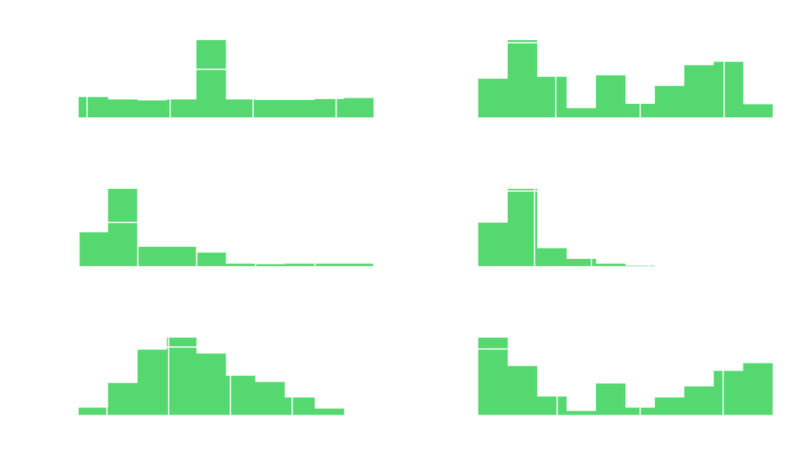

```python
# Create histograms of important variables
df_stats[['Children', 'Age', 'Income', 'Tenure', 'MonthlyCharge', 'Bandwidth_GB_Year']].hist()
plt.savefig('churn_pyplot.jpg')
plt.tight_layout()
# plt.close()
```

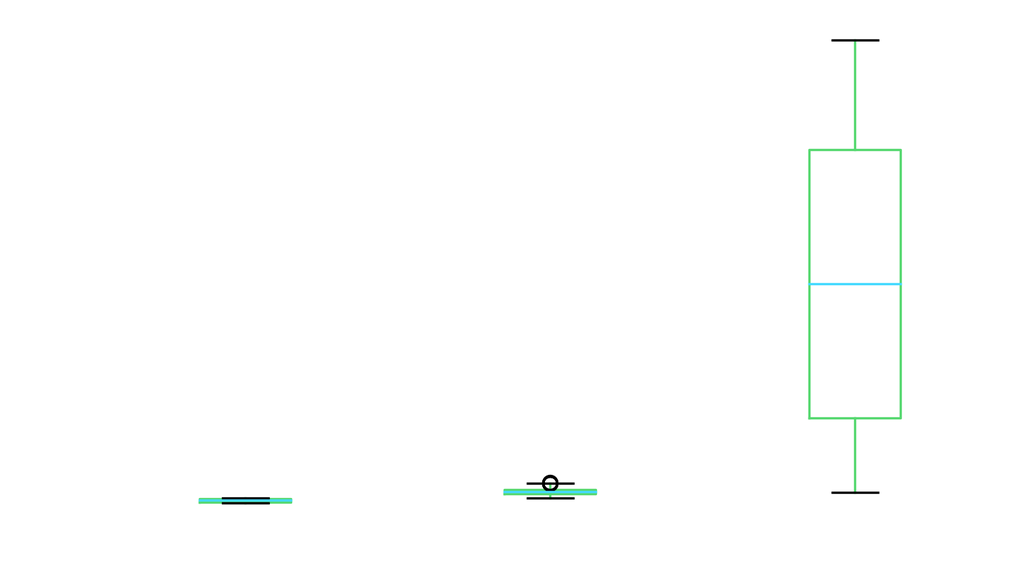

```python
# Some odd distributions here, let's see some box plots for outliers
# Create a boxplot of user duration, payment & usage variables
df_stats.boxplot(['Tenure', 'MonthlyCharge', 'Bandwidth_GB_Year'])
plt.savefig('churn_boxplots.jpg')
```

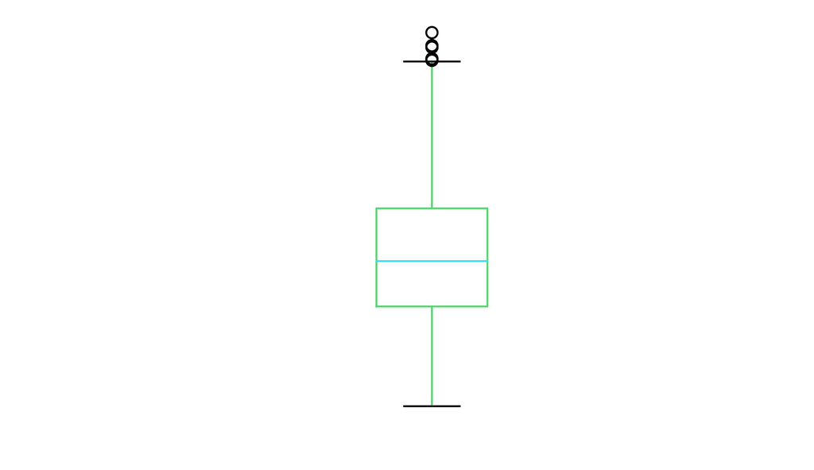

```python
# Let's see monthly charge separately
df_stats.boxplot(['MonthlyCharge'])
# Definitely outliers but not sure how that effects PCA down the line
```

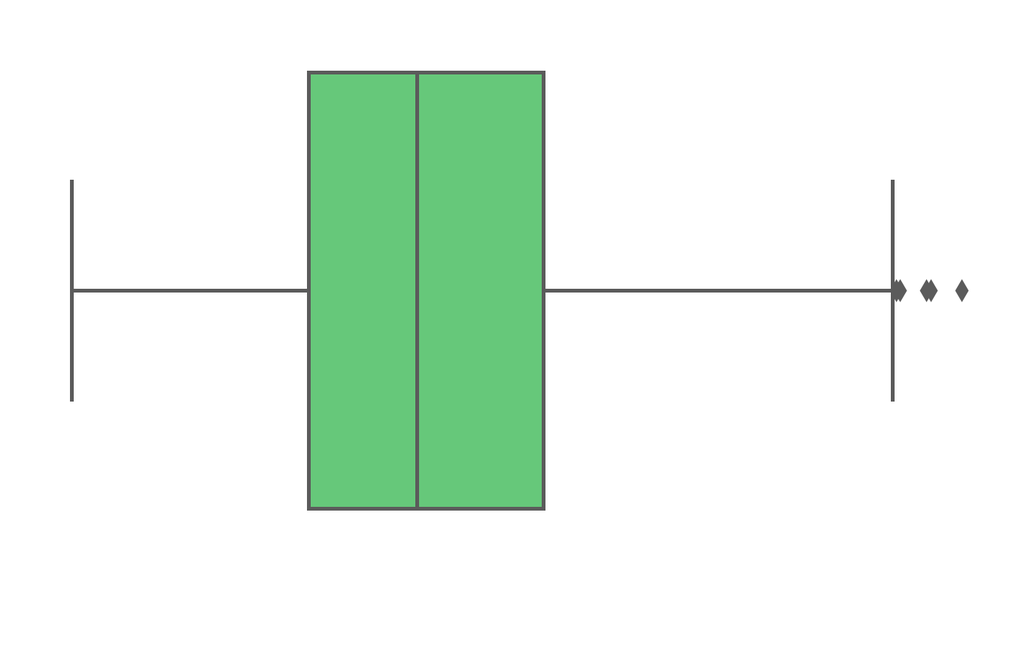

```python
# Let's see a Seaborn boxplot fee & bandwidth
sns.boxplot('MonthlyCharge', data = df_stats)
plt.show()
# Definitely outliers but not sure what to do with them
```

## Extract Clean dataset to 'churn_clean.csv'

```python
# Extract Clean dataset
df_stats.to_csv('churn_clean.csv')
```

```python
# Reload cleaned data & remove all variable except user services payment info and survey data
churn_user = pd.read_csv('churn_clean.csv')
```

```python
# Slice off all but last eleven service realted variables
data = churn_user.loc[:, 'Tenure':'Listening']
data.head()
```

|  | Tenure | MonthlyCharge | Bandwidth_GB_Year | Responses | Fixes | Replacements | Reliability | Options | Respectfulness | Courteous | Listening |
| --- | --- | --- | --- | --- | --- | --- | --- | --- | --- | --- | --- |
| 0 | 6.795513 | 171.449762 | 904.536110 | 5 | 5 | 5 | 3 | 4 | 4 | 3 | 4 |
| 1 | 1.156681 | 242.948015 | 800.982766 | 3 | 4 | 3 | 3 | 4 | 3 | 4 | 4 |
| 2 | 15.754144 | 159.440398 | 2054.706961 | 4 | 4 | 2 | 4 | 4 | 3 | 3 | 3 |
| 3 | 17.087227 | 120.249493 | 2164.579412 | 4 | 4 | 4 | 2 | 5 | 4 | 3 | 3 |
| 4 | 1.670972 | 150.761216 | 271.493436 | 4 | 4 | 4 | 3 | 4 | 4 | 4 | 5 |

## PCA (D206 Performance Lab)

```python
# Import Scikit Learn PCA application
from sklearn.decomposition import PCA
```

```python
# Normalize the data
churn_normalized = (data - data.mean()) / data.std()
```

```python
# Select number of components to extract
pca = PCA(n_components = data.shape[1])
```

```python
# Create a list of PCA names
churn_numeric = data[['Tenure', 'MonthlyCharge', 'Bandwidth_GB_Year', 'Responses',
                       'Fixes', 'Replacements', 'Reliability', 'Options',
                       'Respectfulness', 'Courteous', 'Listening']]
pcs_names = []
for i, col in enumerate(churn_numeric.columns):
    pcs_names.append('PC' + str(i + 1))
print(pcs_names)
```

```
['PC1', 'PC2', 'PC3', 'PC4', 'PC5', 'PC6', 'PC7', 'PC8', 'PC9', 'PC10', 'PC11']
```

```python
# Call PCA application & convert the dataset of 11 variables into a dataset of 11 components
pca.fit(churn_normalized)
churn_pca = pd.DataFrame(pca.transform(churn_normalized),
                        columns = pcs_names)
```

```python
# For a scree plot import matplotlib & seaborn libraries
import matplotlib.pyplot as plt
import seaborn as sns
```

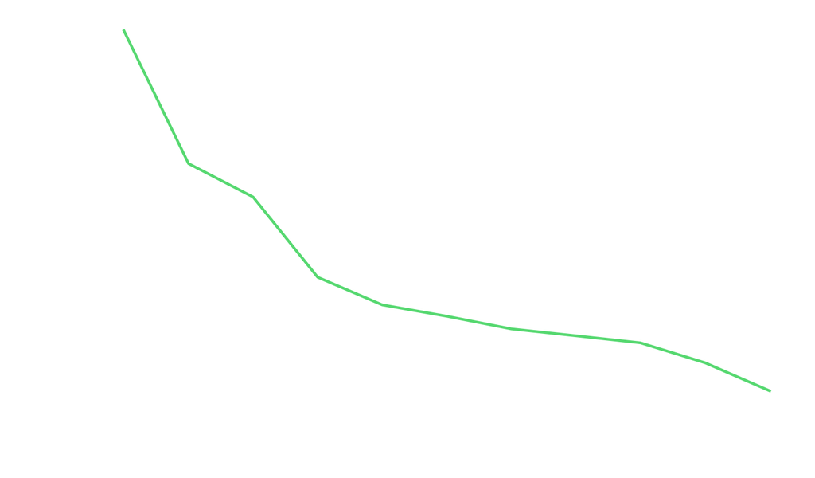

```python
# Run the scree plot
plt.plot(pca.explained_variance_ratio_)
plt.xlabel('Number of Components')
plt.ylabel('Explained Variance')
plt.show();
```

```python
# Extract the eigenvalues
cov_matrix = np.dot(churn_normalized.T, churn_normalized) / data.shape[0]
eigenvalues = [np.dot(eigenvector.T, np.dot(cov_matrix, eigenvector)) for eigenvector in pca.components_]
```

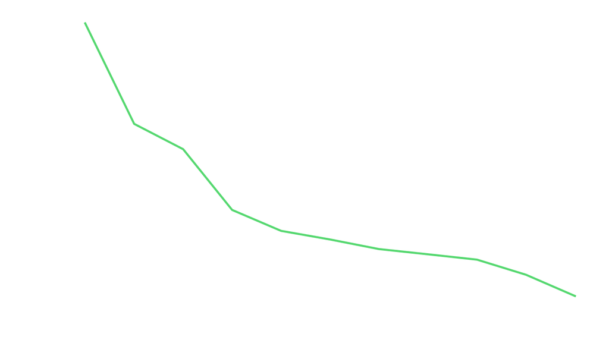

```python
# Plot the eigenvalues
plt.plot(eigenvalues)
plt.xlabel('Number of Components')
plt.ylabel('Eigenvalue')
plt.show();
```

```python
# Select the fewest components
for pc, var in zip(pcs_names, np.cumsum(pca.explained_variance_ratio_)):
    print(pc, var)
```

```
PC1 0.26792660623963066
PC2 0.44053732880229357
PC3 0.5891444522248594
PC4 0.6801579842425083
PC5 0.7513217054372497
PC6 0.8143117094101318
PC7 0.8681970531672316
PC8 0.9171387362588829
PC9 0.9610122820002187
PC10 0.9905736363144831
PC11 1.0
```

```python
# Above, we see that 86% of variance is explained by 7 components
# Create a rotation
rotation = pd.DataFrame(pca.components_.T, columns = pcs_names, index = churn_numeric.columns)
print(rotation)
```

```
                        PC1       PC2       PC3       PC4       PC5       PC6  \
Tenure            -0.010403  0.701838 -0.072209 -0.063594  0.005683 -0.011155
MonthlyCharge      0.000317  0.041147 -0.014151  0.996995 -0.022136  0.015231
Bandwidth_GB_Year -0.012166  0.703079 -0.074222  0.004399  0.009590  0.003466
Responses          0.458932  0.031325  0.281154  0.018568 -0.070233 -0.119149
Fixes              0.434134  0.042559  0.282404  0.007508 -0.106632 -0.169752
Replacements       0.400639  0.034665  0.281118 -0.019631 -0.173742 -0.255336
Reliability        0.145799 -0.050367 -0.567815 -0.010310 -0.171334 -0.483328
Options           -0.175633  0.066334  0.587335 -0.000047  0.135949  0.060124
Respectfulness     0.405207 -0.012680 -0.183447  0.004596 -0.062342  0.064609
Courteous          0.358342 -0.003886 -0.181697 -0.027959 -0.182406  0.806166
Listening          0.308925 -0.017396 -0.131173  0.015574  0.931612 -0.011133

                        PC7       PC8       PC9      PC10      PC11
Tenure             0.007419 -0.011527  0.006935  0.003286 -0.705445
MonthlyCharge     -0.018038 -0.004316  0.023690 -0.013785 -0.047865
Bandwidth_GB_Year  0.003701 -0.002364 -0.008068  0.008529  0.706925
Responses         -0.045963  0.025431 -0.240574  0.793237 -0.004306
Fixes             -0.065414  0.074400 -0.592131 -0.573832 -0.002217
Replacements      -0.146887 -0.396333  0.673088 -0.177665  0.014933
Reliability       -0.443353  0.431528  0.087207  0.018301  0.002283
Options           -0.209767  0.693861  0.265474 -0.042012 -0.002514
Respectfulness     0.757954  0.402835  0.230319 -0.063972  0.001604
Courteous         -0.379136  0.067889  0.067293 -0.040946 -0.006875
Listening         -0.113297 -0.045132  0.046107 -0.042251 -0.002357
```

```python
# Output loadings for components
loadings = pd.DataFrame(pca.components_.T,
                       columns = pcs_names,
                       index = data.columns)
loadings
```

|  | PC1 | PC2 | PC3 | PC4 | PC5 | PC6 | PC7 | PC8 | PC9 | PC10 | PC11 |
| --- | --- | --- | --- | --- | --- | --- | --- | --- | --- | --- | --- |
| Tenure | -0.010403 | 0.701838 | -0.072209 | -0.063594 | 0.005683 | -0.011155 | 0.007419 | -0.011527 | 0.006935 | 0.003286 | -0.705445 |
| MonthlyCharge | 0.000317 | 0.041147 | -0.014151 | 0.996995 | -0.022136 | 0.015231 | -0.018038 | -0.004316 | 0.023690 | -0.013785 | -0.047865 |
| Bandwidth_GB_Year | -0.012166 | 0.703079 | -0.074222 | 0.004399 | 0.009590 | 0.003466 | 0.003701 | -0.002364 | -0.008068 | 0.008529 | 0.706925 |
| Responses | 0.458932 | 0.031325 | 0.281154 | 0.018568 | -0.070233 | -0.119149 | -0.045963 | 0.025431 | -0.240574 | 0.793237 | -0.004306 |
| Fixes | 0.434134 | 0.042559 | 0.282404 | 0.007508 | -0.106632 | -0.169752 | -0.065414 | 0.074400 | -0.592131 | -0.573832 | -0.002217 |
| Replacements | 0.400639 | 0.034665 | 0.281118 | -0.019631 | -0.173742 | -0.255336 | -0.146887 | -0.396333 | 0.673088 | -0.177665 | 0.014933 |
| Reliability | 0.145799 | -0.050367 | -0.567815 | -0.010310 | -0.171334 | -0.483328 | -0.443353 | 0.431528 | 0.087207 | 0.018301 | 0.002283 |
| Options | -0.175633 | 0.066334 | 0.587335 | -0.000047 | 0.135949 | 0.060124 | -0.209767 | 0.693861 | 0.265474 | -0.042012 | -0.002514 |
| Respectfulness | 0.405207 | -0.012680 | -0.183447 | 0.004596 | -0.062342 | 0.064609 | 0.757954 | 0.402835 | 0.230319 | -0.063972 | 0.001604 |
| Courteous | 0.358342 | -0.003886 | -0.181697 | -0.027959 | -0.182406 | 0.806166 | -0.379136 | 0.067889 | 0.067293 | -0.040946 | -0.006875 |
| Listening | 0.308925 | -0.017396 | -0.131173 | 0.015574 | 0.931612 | -0.011133 | -0.113297 | -0.045132 | 0.046107 | -0.042251 | -0.002357 |

```python
# Finally, extract reduced dataset & print 3 components
churn_reduced = churn_pca.iloc[ : , 0:3]
print(churn_reduced)
```

```
           PC1       PC2       PC3
0     1.923875 -1.421955  1.903125
1    -0.199798 -1.706801  0.538766
2    -0.667923 -0.985940  0.227390
3     0.046465 -0.730628  2.282040
4     1.326741 -1.924880  0.825729
...        ...       ...       ...
9995 -2.097964  1.961837  0.104147
9996  1.917485  1.645946  0.611009
9997  1.431918  0.323573  0.028288
9998  2.011460  2.187756 -0.079864
9999 -2.266364  1.591986 -0.819973

[10000 rows x 3 columns]
```

## Part III: Data Cleaning

### D. Data Cleaning Summary

D1.**Cleaning Findings**: There was much missing data with meaningful variable fields including Children, Age, Income, Tenure and Bandwidth_GB_Year. Given mean and variance of these variables, it seemed reasonable to impute missing values with median values. Many categorical (such as whether or not the customer was "Techie") & non-numeric (columns for customer ID numbers & related customer transaction IDs) data were not included in analysis given they seemed less meaningful to interpretation and decision-making. The anomalies discovered were not significant & were mitigated as follows.

D2.**Justification of Mitigation Methods**: Mitigated missing values with imputation using median values. MonthlyCharge variable shows outliers so left alone. This does not seem significant to this analysis.

D3.**Summary of Outcomes**: Cleaned dataset to leave remaining variables describing customer tenure, monthly service charge, yearly bandwidth usage & responses to survey. It seems pretty straightforward at this point.</b>

D4.**Mitigation Code**: (see code above and Panopto recording)

D5.**Clean Data**: (see attached file **'churn_clean.csv'**)

D6.**Limitations**: Limitations given the telecom company data set are that the data are not coming from a warehouse. In this scenario, it is as though I initiated and gathered the data. So, I am not able to reach out to the staff that organized & gathered this information to ask them why certain NAs are there, why are fields such as age or yearly bandwidth usage missing information that might be relevant to answering questions about customer retention or churn. In a real world project, you would be able to go down to the department where these folks worked and fill in the empty fields or discover why fields are left blank.

D7. The accurate factual data for missing fields that might be recoverable given the ability to access the staff in the data warehouse, such as company tenure with the company, may give a slighty different overall picture to the analysis. While imputation may provide a path to move forward and give decision-makers reasonable answers, there really is no reason for these data to be missing. The limitations here could be remedied by instituting stricter data acquisition procedures, follow-ups & feedback.

### E. PCA Application

E1. **Principal Components**: The principal components, and what I determined to be "most important", in this dataset include survey responses to:

- Timely Responses
- Timely Fixes
- Timely Replacements
- Respectful Response

E3. **Benefits**: The loadings suggest the variables involved in timely action with regard to customer satisfaction (Responses, Fixes, Replacements & Respectfulness) should be given greater emphasis and hopefully help reduce the churn rate from the large number of 27% & "increase the retention period of customers" by targeting more resources in the direction prompt customer service (Ahmad, 2019, p. 1). Again, this seems an intuitive result but now decision-makers in the company of reasonable verification of what might have been a "hunch".

## Part IV: Supporting Documents

### F. Video

https://wgu.hosted.panopto.com/Panopto/Pages/Viewer.aspx?id=9c94329b-551f-44de-a598-ad1d013eecff

### G. Sources for Third-Party Code

Cmdline. (2018, March 20). *How To Change Column Names and Row Indexes in Pandas?* Python and R Tips.  
https://cmdlinetips.com/2018/03/how-to-change-column-names-and-row-indexes-in-pandas/

Larose, C. D. & Larose, D. T. (2019). *Data Science: Using Python and R.* John Wiley & Sons, Inc.

Poulson, B. (2016). *Data Science Foundations: Data Mining* LinkedIn Learning.  
https://www.linkedin.com/learning/data-science-foundations-data-mining/anomaly-detection-in-python?u=2045532

Sree. (2020, October 26). *Predict Customer Churn in Python.* Towards Data Science.  
https://towardsdatascience.com/predict-customer-churn-in-python-e8cd6d3aaa7

VanderPlas, J. (2017). *Python Data Science Handbook: Essential Tools for Working with Data.*  
O'Reilly Media, Inc.

### H. Sources

Ahmad, A. K., Jafar, A & Aljoumaa, K. (2019, March 20). Customer churn prediction in telecom using machine  
learning in big data platform. Journal of Big Data.  
https://journalofbigdata.springeropen.com/articles/10.1186/s40537-019-0191-6

Altexsoft. (2019, March 27). *Customer Churn Prediction Using Machine Learning: Main Approaches and Models*.  
Altexsoft.  
https://www.altexsoft.com/blog/business/customer-churn-prediction-for-subscription-businesses-using-machine-learning-main-approaches-and-models/

Frohbose, F. (2020, November 24). *Machine Learning Case Study: Telco Customer Churn Prediction*.  
Towards Data Science.  
https://towardsdatascience.com/machine-learning-case-study-telco-customer-churn-prediction-bc4be03c9e1d

Mountain, A. (2014, August 11). *Data Cleaning*. Better Evaluation.  
https://www.betterevaluation.org/en/evaluation-options/data_cleaning